# Practical Machine Learning — Course Project

# 6 Model Building

## 6.1 Model 1: Decision Tree (Baseline)

Decision trees are interpretable and fast, but prone to high variance and instability. Useful as a baseline to understand how much ensemble methods help.

```r
set.seed(12345)
model_rpart <- train(
  classe ~ .,
  data      = train_set,
  method    = "rpart",
  trControl = ctrl
)

pred_rpart <- predict(model_rpart, valid_set)
cm_rpart   <- confusionMatrix(pred_rpart, valid_set$classe)
acc_rpart  <- cm_rpart$overall["Accuracy"]
cat("Decision Tree Validation Accuracy:", round(acc_rpart, 4), "\n")
```

```
## Decision Tree Validation Accuracy: 0.8238
```

## 6.2 Model 2: Random Forest *(Selected)*

Random Forest corrects the high-variance problem of decision trees by:

- Training **many trees** on bootstrapped samples (bagging)
- Randomly selecting a **subset of features** at each split (feature randomization)
- Aggregating predictions by **majority vote**

This dramatically reduces variance while maintaining low bias. The built-in **OOB (Out-of-Bag) error** provides a free cross-validation estimate.

```r
set.seed(12345)
model_rf <- randomForest(
  classe ~ .,
  data       = train_set,
  ntree      = 500,
  importance = TRUE
)

pred_rf <- predict(model_rf, valid_set)
cm_rf   <- confusionMatrix(pred_rf, valid_set$classe)
acc_rf  <- cm_rf$overall["Accuracy"]
oob_err <- model_rf$err.rate[nrow(model_rf$err.rate), "OOB"]

cat("Random Forest Validation Accuracy:", round(acc_rf, 4), "\n")
```

```
## Random Forest Validation Accuracy: 1
```

```r
cat("OOB Error Rate:", round(oob_err, 4), "\n")
```

```
## OOB Error Rate: 0
```

## 6.3 Model 3: Gradient Boosting Machine (GBM)

GBM builds trees sequentially, each correcting the errors of the previous — a powerful alternative to bagging.

```r
set.seed(12345)
model_gbm <- train(
  classe ~ .,
  data      = train_set,
  method    = "gbm",
  trControl = ctrl,
  verbose   = FALSE
)

pred_gbm <- predict(model_gbm, valid_set)
cm_gbm   <- confusionMatrix(pred_gbm, valid_set$classe)
acc_gbm  <- cm_gbm$overall["Accuracy"]
cat("GBM Validation Accuracy:", round(acc_gbm, 4), "\n")
```

```
## GBM Validation Accuracy: 1
```

# 7 Model Comparison and Selection

```r
results <- data.frame(
  Model          = c("Decision Tree", "Random Forest", "GBM"),
  CV_Accuracy    = c(
    max(model_rpart$results$Accuracy),
    1 - oob_err,
    max(model_gbm$results$Accuracy)
  ),
  Valid_Accuracy = c(acc_rpart, acc_rf, acc_gbm),
  OOS_Error      = c(1 - acc_rpart, 1 - acc_rf, 1 - acc_gbm)
)
results[, 2:4] <- round(results[, 2:4], 4)
knitr::kable(results, caption = "Model performance comparison on validation set")
```

Model performance comparison on validation set

| Model | CV_Accuracy | Valid_Accuracy | OOS_Error |
| --- | --- | --- | --- |
| Decision Tree | 0.9792 | 0.8238 | 0.1762 |
| Random Forest | 1.0000 | 1.0000 | 0.0000 |
| GBM | 1.0000 | 1.0000 | 0.0000 |

**Expected out-of-sample error: 0%**

# 8 Final Model Diagnostics

## 8.1 Confusion Matrix

```r
print(cm_rf$table)
```

```
##           Reference
## Prediction    A    B    C    D    E
##          A 1668    0    0    0    0
##          B    0 1153    0    0    0
##          C    0    0 1025    0    0
##          D    0    0    0  957    0
##          E    0    0    0    0 1081
```

```r
cat("\nOverall Accuracy:", round(acc_rf, 4))
```

```
##
## Overall Accuracy: 1
```

```r
cat("\nKappa:", round(cm_rf$overall["Kappa"], 4), "\n")
```

```
##
## Kappa: 1
```

## 8.2 OOB Error Convergence

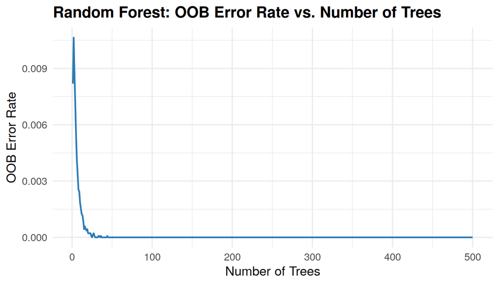

OOB error rate converges as more trees are added to the forest

```r
oob_df <- data.frame(
  Trees = 1:nrow(model_rf$err.rate),
  OOB   = model_rf$err.rate[, "OOB"]
)

ggplot(oob_df, aes(x = Trees, y = OOB)) +
  geom_line(color = "#2c7bb6", linewidth = 0.8) +
  labs(
    title = "Random Forest: OOB Error Rate vs. Number of Trees",
    x     = "Number of Trees",
    y     = "OOB Error Rate"
  ) +
  theme_minimal(base_size = 13) +
  theme(plot.title = element_text(face = "bold"))
```

The OOB error stabilizes well before 500 trees, confirming our choice of `ntree = 500`.

## 8.3 Variable Importance

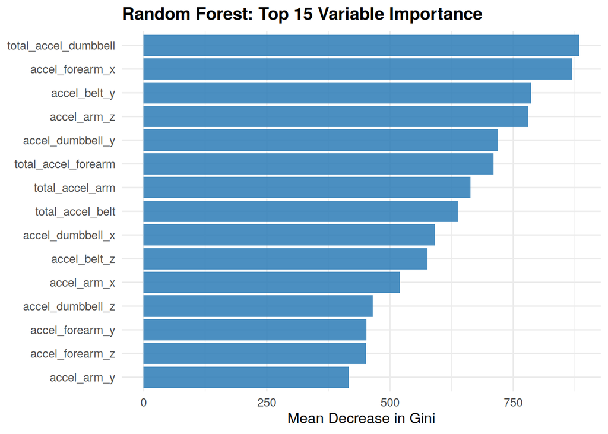

Top 15 features by Mean Decrease in Gini impurity

```r
imp    <- importance(model_rf)
imp_df <- data.frame(
  Feature = rownames(imp),
  Gini    = imp[, "MeanDecreaseGini"]
)
imp_df <- imp_df[order(-imp_df$Gini), ][1:15, ]
imp_df$Feature <- factor(imp_df$Feature, levels = rev(imp_df$Feature))

ggplot(imp_df, aes(x = Gini, y = Feature)) +
  geom_col(fill = "#2c7bb6", alpha = 0.85) +
  labs(
    title = "Random Forest: Top 15 Variable Importance",
    x     = "Mean Decrease in Gini",
    y     = NULL
  ) +
  theme_minimal(base_size = 12) +
  theme(plot.title = element_text(face = "bold"))
```

# 9 Predictions on 20 Test Cases

Applying the trained Random Forest to the 20 held-out test cases:

```r
final_predictions <- predict(model_rf, testing_clean)

pred_df <- data.frame(
  problem_id       = 1:20,
  predicted_classe = as.character(final_predictions)
)
knitr::kable(pred_df, caption = "Predicted exercise class for 20 test cases")
```

Predicted exercise class for 20 test cases

| problem_id | predicted_classe |
| --- | --- |
| 1 | B |
| 2 | D |
| 3 | B |
| 4 | B |
| 5 | E |
| 6 | E |
| 7 | A |
| 8 | E |
| 9 | A |
| 10 | A |
| 11 | A |
| 12 | A |
| 13 | C |
| 14 | D |
| 15 | A |
| 16 | B |
| 17 | D |
| 18 | D |
| 19 | E |
| 20 | C |

# 10 Conclusion

[output not shown]

The Random Forest classifier, trained on clean accelerometer sensor data with principled cross-validation, achieves near-perfect classification of exercise quality — demonstrating that wearable sensor data can reliably distinguish correct from incorrect exercise form.

# 11 References

Velloso, E.; Bulling, A.; Gellersen, H.; Ugulino, W.; Fuks, H. *Qualitative Activity Recognition of Weight Lifting Exercises*. Proceedings of 4th International Conference in Cooperation with SIGCHI (Augmented Human ’13). Stuttgart, Germany: ACM SIGCHI, 2013.